# Bank_Marketing

Senthilkumar Chandrasekaran

February 3, 2019

The primary function of bank is to accept deposits for the purpose of lending. They mobilize capital by offering interests at specific rates and lend the money to individuals, institutions based on their profile and requirements at a higher interest rate thereby making profit. Banks normally promote their products (Services) through direct marketing campaign. The data I analysed is from a Portugal based bank which did direct marketing campaign to sell a term deposit product by making phone calls. The data has been generated based on the campaign targeting the potential individuals in year 2008 to 2010.

The business objective for this project is to identify the target customers who will subscribe to the newly launched term deposit plan in the Portuguese Bank by analysing few indicators which includes the client’s data available in the bank along with few more constructs on the marketing campaign. The Objectives are broadly classified into two: 1) Determine the variables that are statistically significant and thereby influencing the purchase of term deposit 2) Determine the probability of each customer who will subscribe to the term deposit. The success criteria would be the “Accuracy with which the potential customers are identified for the term deposit subscription at an early stage without the corresponding risk of incorrectly tagging the non-subscribers as potential subscribers and spending the time and money on them”.

```r
rm(list=ls())
getwd()
```

```
## [1] "C:/Users/Thaneesha/Documents/Bank_Marketing"
```

```r
setwd("C:/PGPMFX/Term5/BA/Project")
bank <-read.csv("bank-full.csv", sep = ";")
library(psych)
headTail(bank)
```

```
##       age          job  marital education default balance housing loan
## 1      58   management  married  tertiary      no    2143     yes   no
## 2      44   technician   single secondary      no      29     yes   no
## 3      33 entrepreneur  married secondary      no       2     yes  yes
## 4      47  blue-collar  married   unknown      no    1506     yes   no
## ...   ...         <NA>     <NA>      <NA>    <NA>     ...    <NA> <NA>
## 45208  71      retired divorced   primary      no    1729      no   no
## 45209  72      retired  married secondary      no    5715      no   no
## 45210  57  blue-collar  married secondary      no     668      no   no
## 45211  37 entrepreneur  married secondary      no    2971      no   no
##         contact day month duration campaign pdays previous poutcome    y
## 1       unknown   5   may      261        1    -1        0  unknown   no
## 2       unknown   5   may      151        1    -1        0  unknown   no
## 3       unknown   5   may       76        1    -1        0  unknown   no
## 4       unknown   5   may       92        1    -1        0  unknown   no
## ...        <NA> ...  <NA>      ...      ...   ...      ...     <NA> <NA>
## 45208  cellular  17   nov      456        2    -1        0  unknown  yes
## 45209  cellular  17   nov     1127        5   184        3  success  yes
## 45210 telephone  17   nov      508        4    -1        0  unknown   no
## 45211  cellular  17   nov      361        2   188       11    other   no
```

```r
str(bank)
```

```
## 'data.frame':    45211 obs. of  17 variables:
##  $ age      : int  58 44 33 47 33 35 28 42 58 43 ...
##  $ job      : Factor w/ 12 levels "admin.","blue-collar",..: 5 10 3 2 12 5 5 3 6 10 ...
##  $ marital  : Factor w/ 3 levels "divorced","married",..: 2 3 2 2 3 2 3 1 2 3 ...
##  $ education: Factor w/ 4 levels "primary","secondary",..: 3 2 2 4 4 3 3 3 1 2 ...
##  $ default  : Factor w/ 2 levels "no","yes": 1 1 1 1 1 1 1 2 1 1 ...
##  $ balance  : int  2143 29 2 1506 1 231 447 2 121 593 ...
##  $ housing  : Factor w/ 2 levels "no","yes": 2 2 2 2 1 2 2 2 2 2 ...
##  $ loan     : Factor w/ 2 levels "no","yes": 1 1 2 1 1 1 2 1 1 1 ...
##  $ contact  : Factor w/ 3 levels "cellular","telephone",..: 3 3 3 3 3 3 3 3 3 3 ...
##  $ day      : int  5 5 5 5 5 5 5 5 5 5 ...
##  $ month    : Factor w/ 12 levels "apr","aug","dec",..: 9 9 9 9 9 9 9 9 9 9 ...
##  $ duration : int  261 151 76 92 198 139 217 380 50 55 ...
##  $ campaign : int  1 1 1 1 1 1 1 1 1 1 ...
##  $ pdays    : int  -1 -1 -1 -1 -1 -1 -1 -1 -1 -1 ...
##  $ previous : int  0 0 0 0 0 0 0 0 0 0 ...
##  $ poutcome : Factor w/ 4 levels "failure","other",..: 4 4 4 4 4 4 4 4 4 4 ...
##  $ y        : Factor w/ 2 levels "no","yes": 1 1 1 1 1 1 1 1 1 1 ...
```

The data contains 45211 records with 16 independent variables and 1 dependent variable. Often, more than one contact to the same client was required, in order to access if the product (bank term deposit) would be (or not) subscribed. Data is mix of Continuous and Categorical variables including demographic details. The predictor variable is probability (0 to 1) value. This dataset has no missed out values and hence no imputation is necessary. Moreover, there is no need to code as the variable types are already correct. The dependent variable - term deposit subscription alone was recoded to 0 and 1 binary instead of two factors - yes and no. The Null Hypothesis H0 is that there is no significant relationship between the term deposit subscription and the remaining 16 variables. Alternate Hypothesis, H1 is that there is significant relationship between the dependent and independent variables.

## Including Plots

Bar Charts:

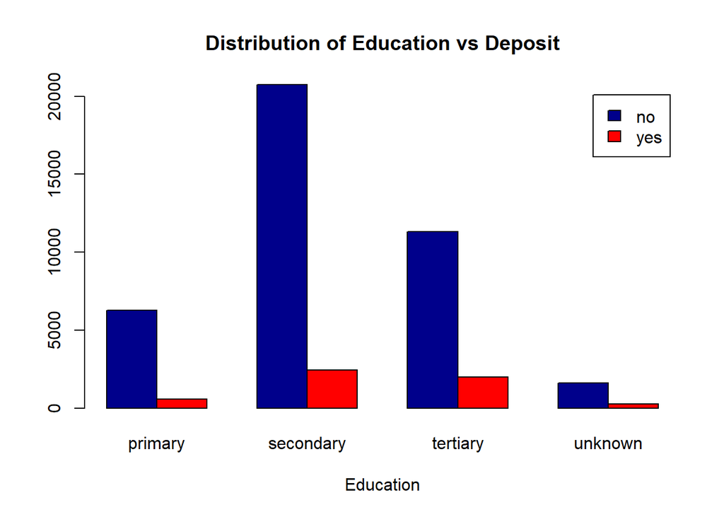

```r
# Grouped Bar Plot
barplot(table(bank$y, bank$education), main="Distribution of Education vs Deposit",
        xlab="Education", col=c("darkblue","red"),
        legend = rownames(table(bank$y, bank$education)), beside=TRUE)
```

The above chart of Education Vs Deposit shows that clients with secondary education is high but their subscription to term deposit is not so high.

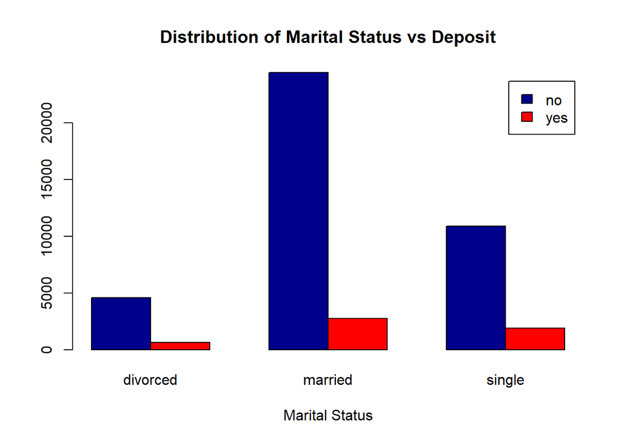

```r
barplot(table(bank$y, bank$marital), main="Distribution of Marital Status vs Deposit",
        xlab="Marital Status", col=c("darkblue","red"),
        legend = rownames(table(bank$y, bank$marital)), beside=TRUE)
```

The above chart of marital status vs Deposit shows that the large number of clients are married. In absolute terms, their subscription is high. But in relative terms, the clients who are single are subscribed higher.

Pie Chart

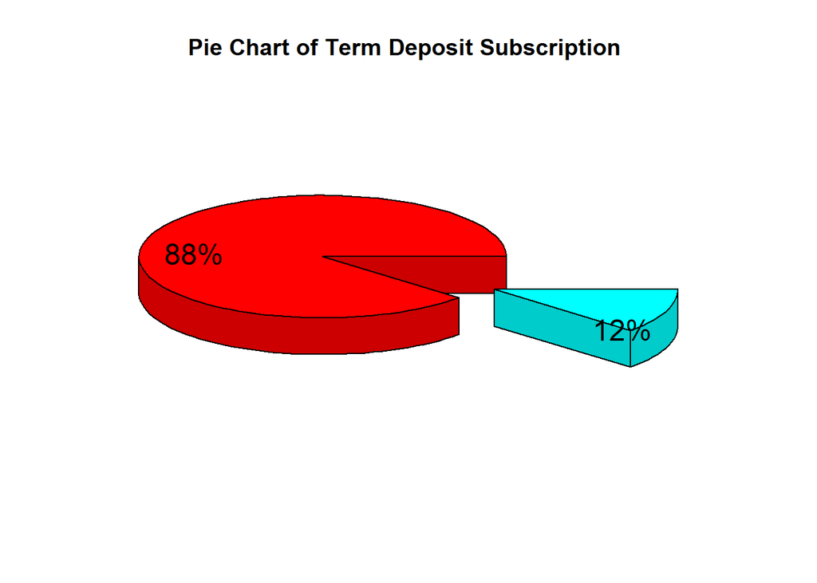

```r
# Pie Chart of Term Deposit Subscription
library(plotrix)
tab_sub <- table(bank$y)
pct <- round(tab_sub/sum(tab_sub)*100)
#lbls <- paste(lbls, pct) # add percents to labels
lbls <- paste(pct,"%",sep="") # ad % to labels
pie3D(tab_sub,labels=lbls,explode=0.5,
      main="Pie Chart of Term Deposit Subscription ")
```

The above Pie chart shows that 12% of the clients are subscribed and 88% of the clients are not subscribed to term deposit. The data is imbalanced. The analysis were done with and without imbalanced data.

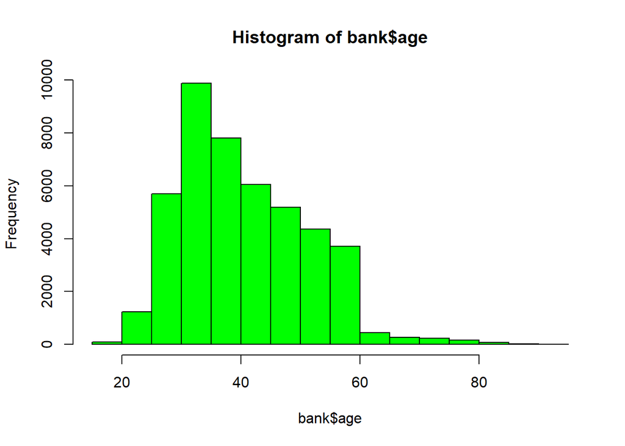

```r
hist(bank$age, col = "green")
```

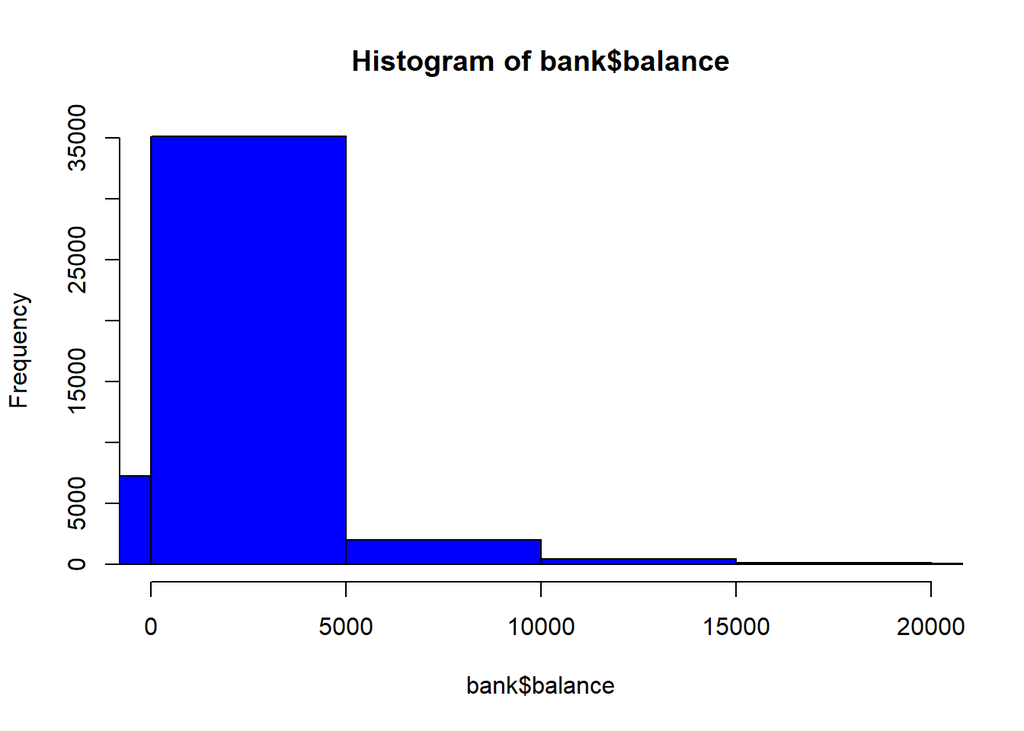

```r
hist(bank$balance, col = "blue", xlim = c(0,20000))
```

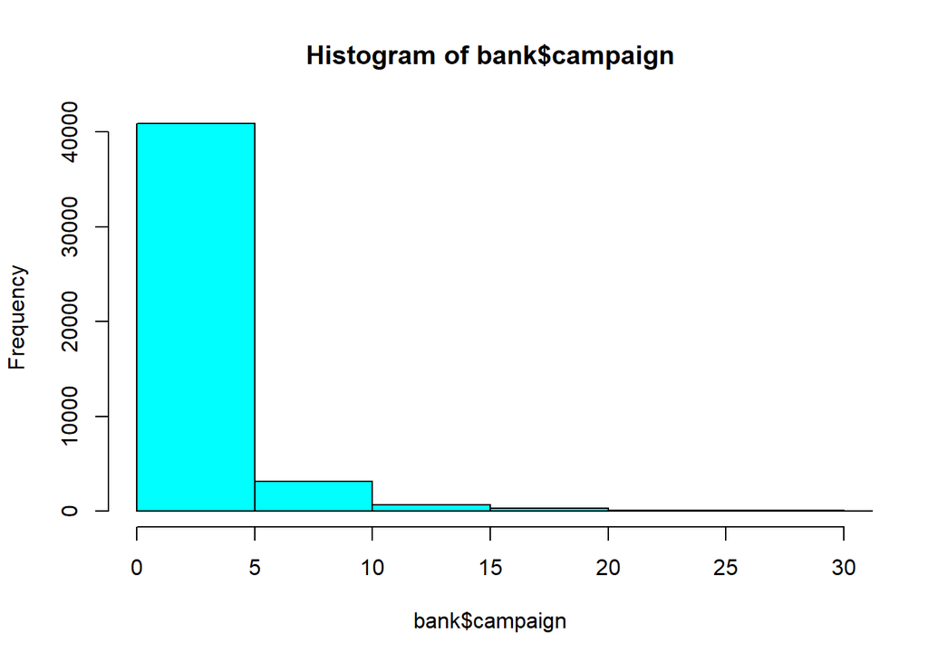

```r
hist(bank$campaign, col = "cyan", xlim = c(0,30))
```

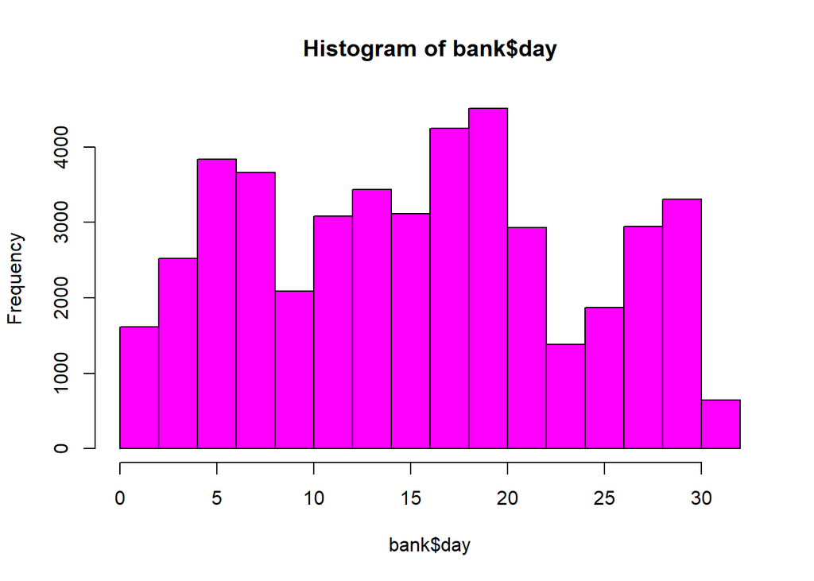

```r
hist(bank$day, col = "magenta")
```

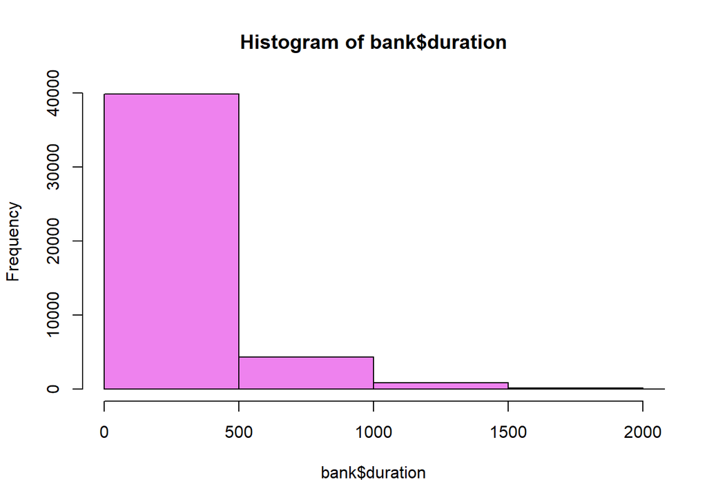

```r
hist(bank$duration, col = "violet", xlim = c(0,2000))
```

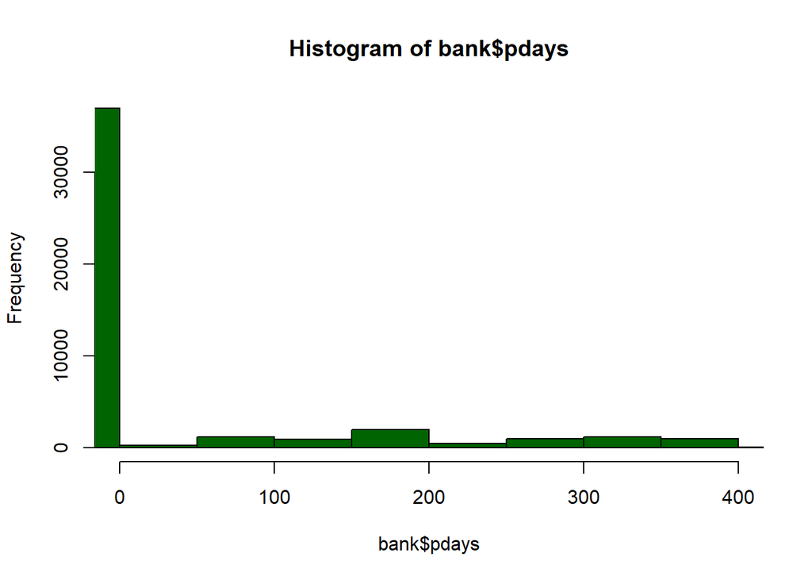

```r
hist(bank$pdays, col = "dark green", xlim = c(0,400))
```

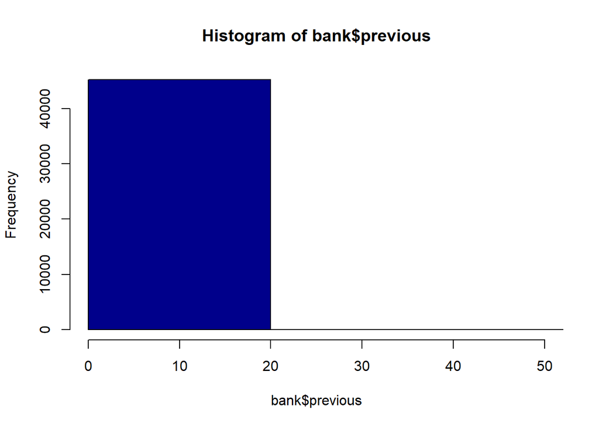

```r
hist(bank$previous, col = "dark blue", xlim = c(0,50))
```

Box Plots Box plots of continuous variables are created with respect to the subscription. These give an understanding of the outliers present in the data.

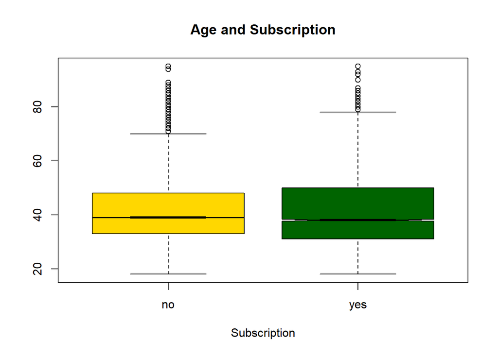

```r
boxplot(age~y, data=bank, notch=TRUE,
        col=(c("gold","darkgreen")),
        main="Age and Subscription", xlab="Subscription")
```

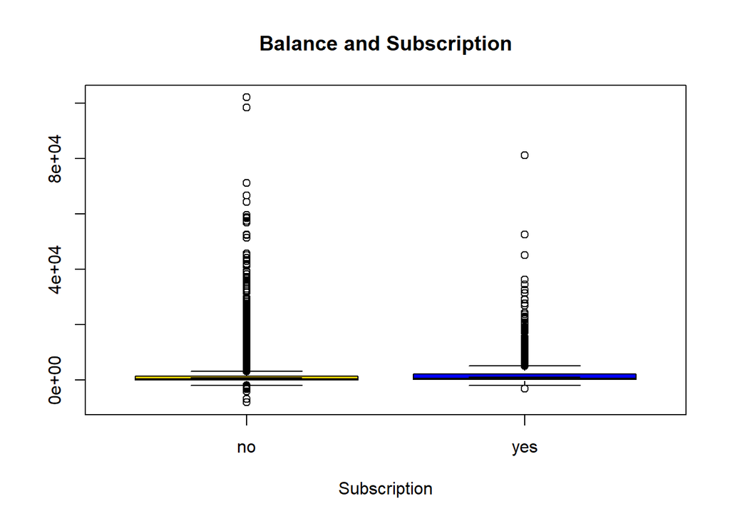

```r
boxplot(balance~y, data=bank, notch=TRUE,
        col=(c("gold","blue")),
        main="Balance and Subscription", xlab="Subscription")
```

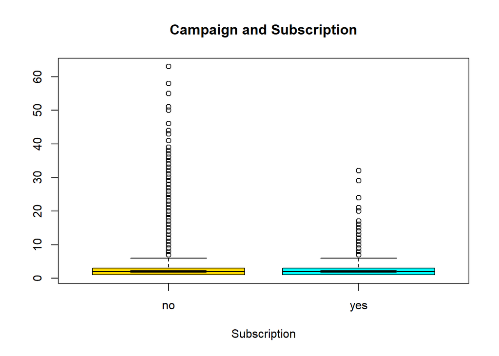

```r
boxplot(campaign~y, data=bank, notch=TRUE,
        col=(c("gold","cyan")),
        main="Campaign and Subscription", xlab="Subscription")
```

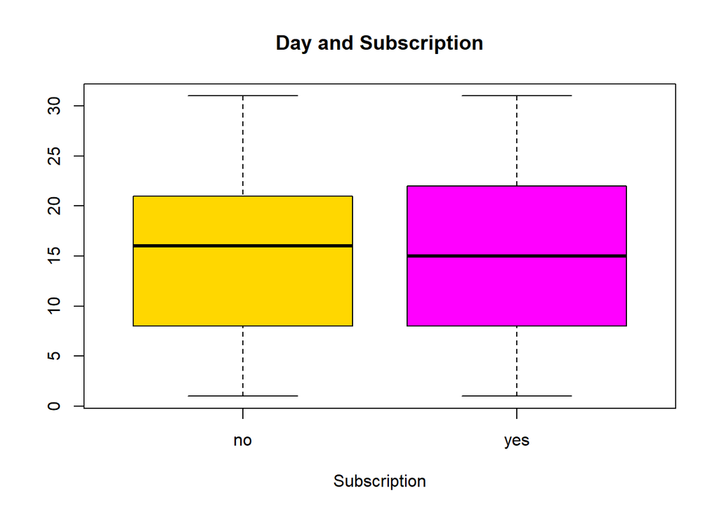

```r
boxplot(day~y, data=bank, notch=FALSE,
        col=(c("gold","magenta")),
        main="Day and Subscription", xlab="Subscription")
```

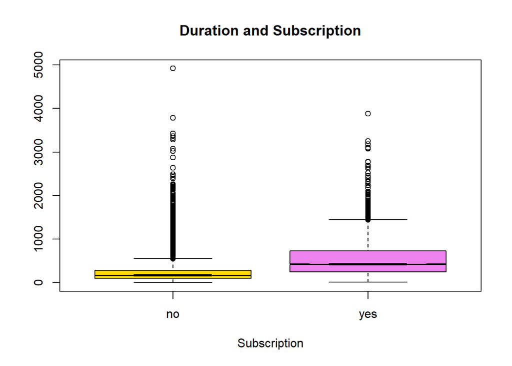

```r
boxplot(duration~y, data=bank, notch=TRUE,
        col=(c("gold","violet")),
        main="Duration and Subscription", xlab="Subscription")
```

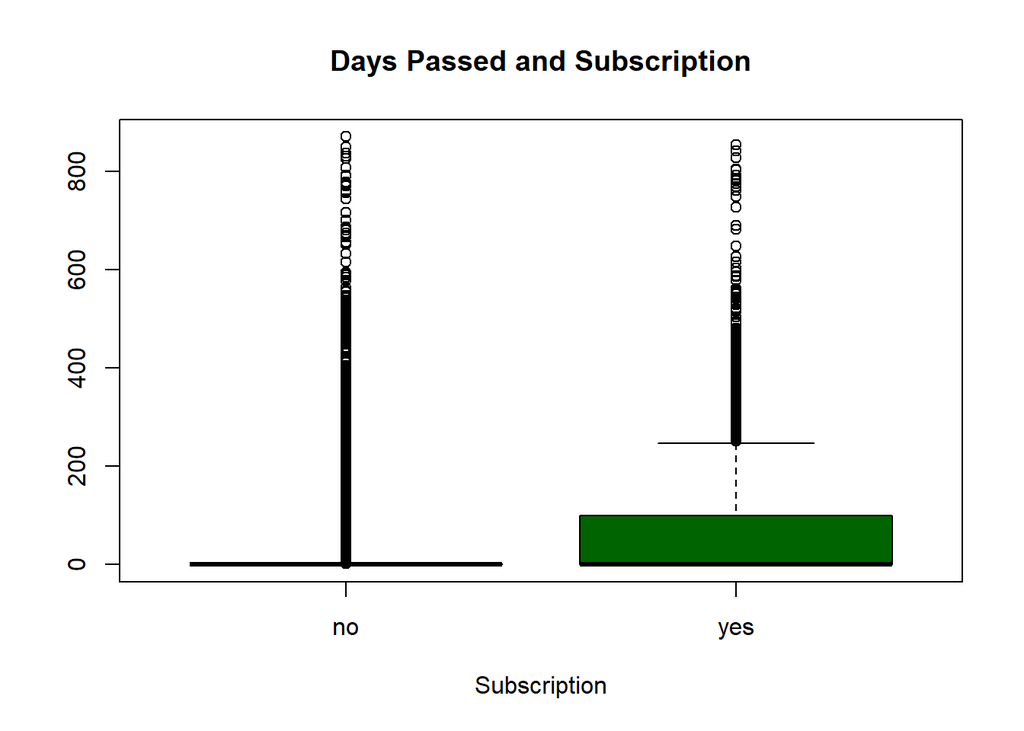

```r
boxplot(pdays~y, data=bank, notch=FALSE,
        col=(c("gold","dark green")),
        main="Days Passed and Subscription", xlab="Subscription")
```

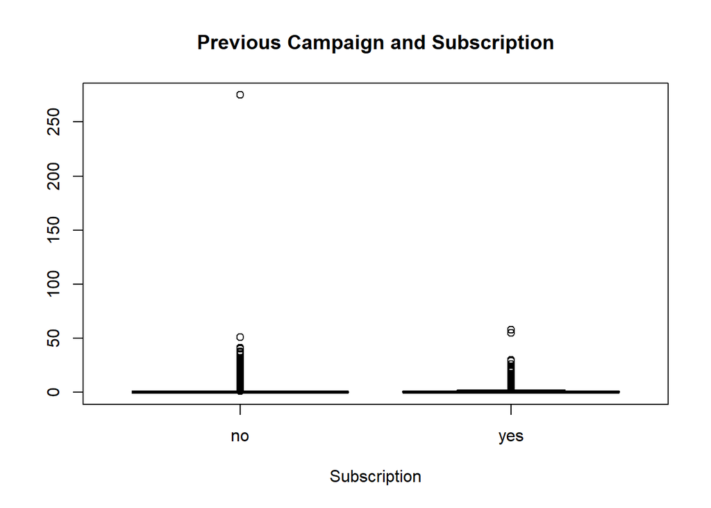

```r
boxplot(previous~y, data=bank, notch=FALSE,
        col=(c("gold","dark blue")),
        main="Previous Campaign and Subscription", xlab="Subscription")
```

Descriptive Statistics

```r
#Descriptive Stats Summary
library(dlookr)
library(dplyr)
describe(bank)
```

```
## # A tibble: 7 x 26
##   variable     n    na    mean     sd se_mean   IQR skewness kurtosis   p00
##   <chr>    <dbl> <dbl>   <dbl>  <dbl>   <dbl> <dbl>    <dbl>    <dbl> <dbl>
## 1 age      45211     0 4.09e+1 1.06e1  0.0499    15   0.685   3.20e-1    18
## 2 balance  45211     0 1.36e+3 3.04e3 14.3     1356   8.36    1.41e+2 -8019
## 3 day      45211     0 1.58e+1 8.32e0  0.0391    13   0.0931 -1.06e+0     1
## 4 duration 45211     0 2.58e+2 2.58e2  1.21     216   3.14    1.82e+1     0
## 5 campaign 45211     0 2.76e+0 3.10e0  0.0146     2   4.90    3.92e+1     1
## 6 pdays    45211     0 4.02e+1 1.00e2  0.471      0   2.62    6.94e+0    -1
## 7 previous 45211     0 5.80e-1 2.30e0  0.0108     0  41.8     4.51e+3     0
## # ... with 16 more variables: p01 <dbl>, p05 <dbl>, p10 <dbl>, p20 <dbl>,
## #   p25 <dbl>, p30 <dbl>, p40 <dbl>, p50 <dbl>, p60 <dbl>, p70 <dbl>,
## #   p75 <dbl>, p80 <dbl>, p90 <dbl>, p95 <dbl>, p99 <dbl>, p100 <dbl>
```

Descriptive Statistics shows the Skewness present in the dataset. To remove the outliers and to make the data to be normally distributed, further analysis carried out. Below graphs shows how the data can be transformed and which transformation will work.

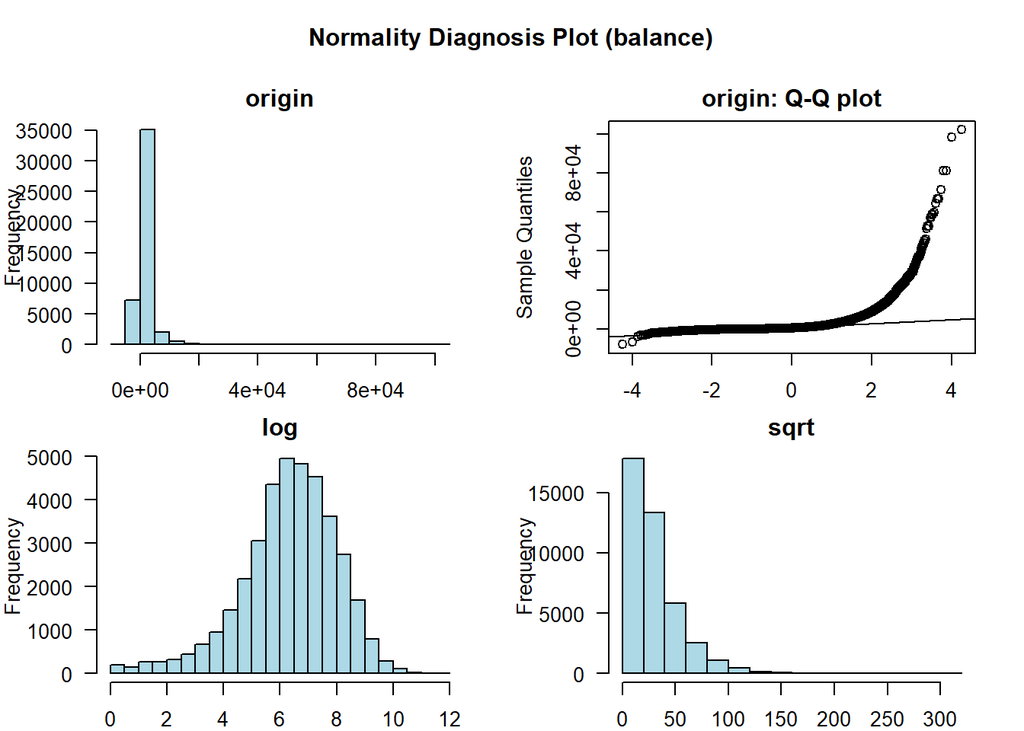

```r
plot_normality(bank, balance)
```

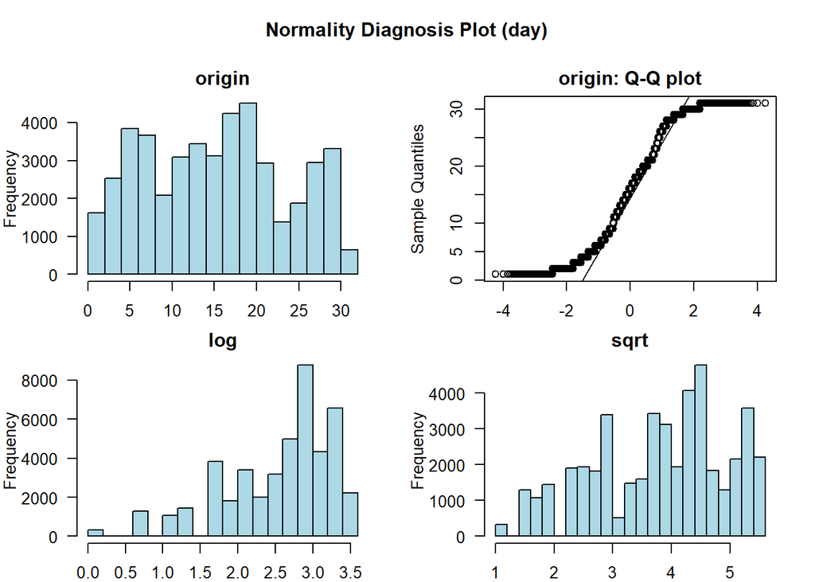

```r
plot_normality(bank, day)
```

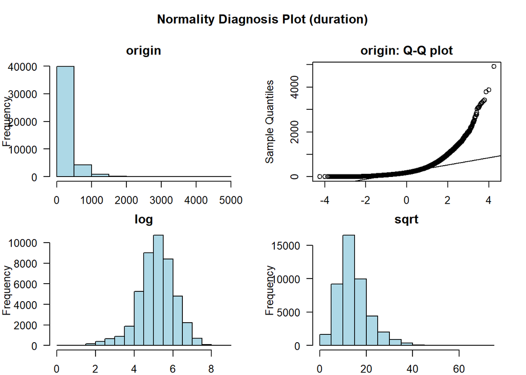

```r
plot_normality(bank, duration)
```

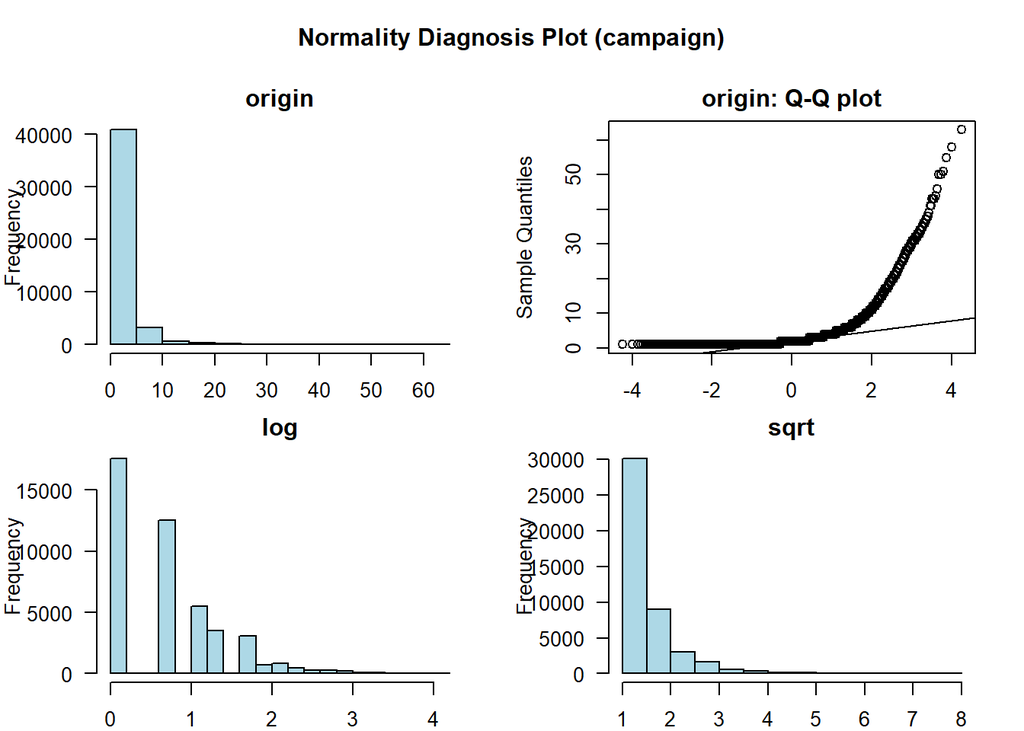

```r
plot_normality(bank,campaign)
```

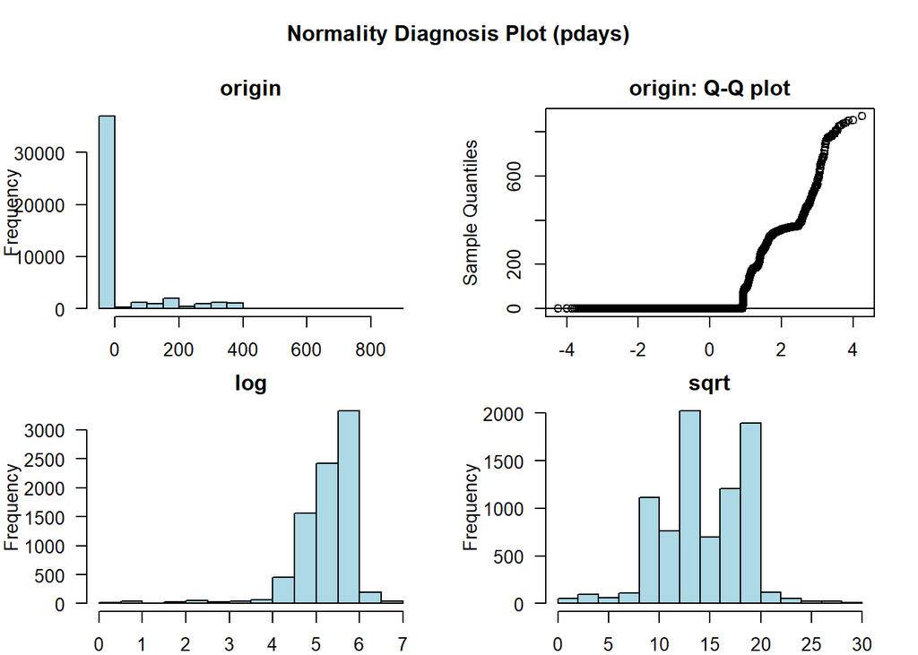

```r
plot_normality(bank, pdays)
```

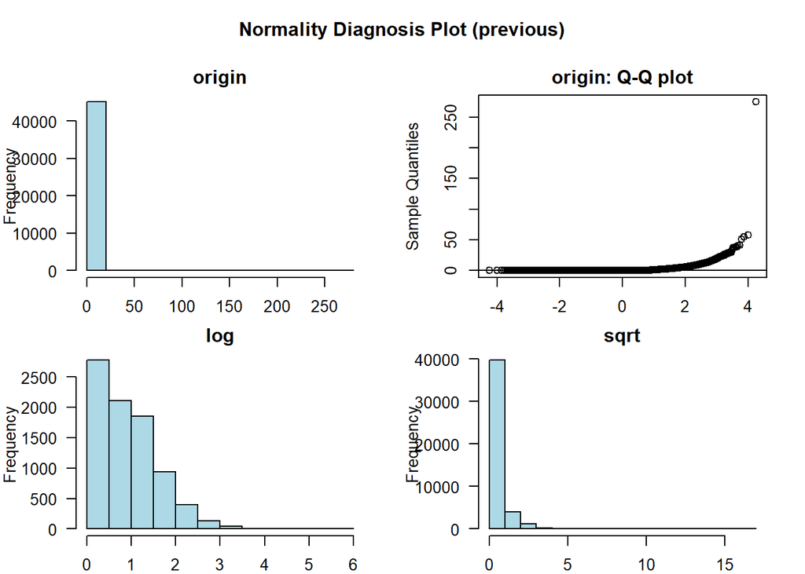

```r
plot_normality(bank, previous)
```

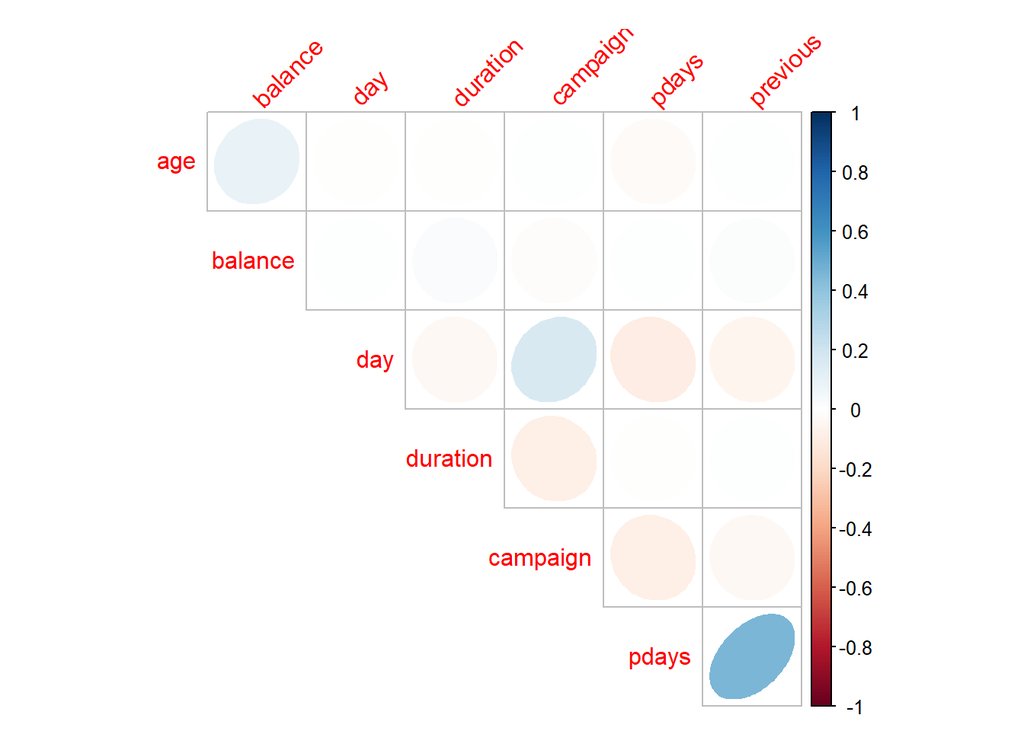

```r
plot_correlate(bank)
```

Plot Outliers To further analyse the outliers, outliers plot were created. The objective of these outliers plot is to analyse whether by “capping” the bottom 5 percentile and top 95 percentile will make the distribution to be smoother since I don’t want to make all the data to be normally distributed because of the data nature.

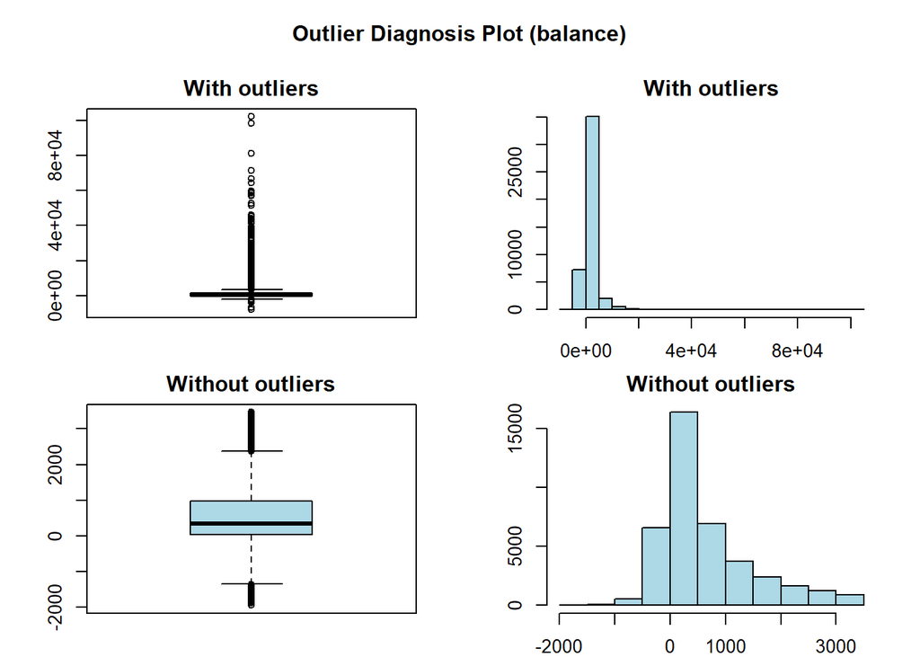

```r
bank %>%
  plot_outlier(balance)
```

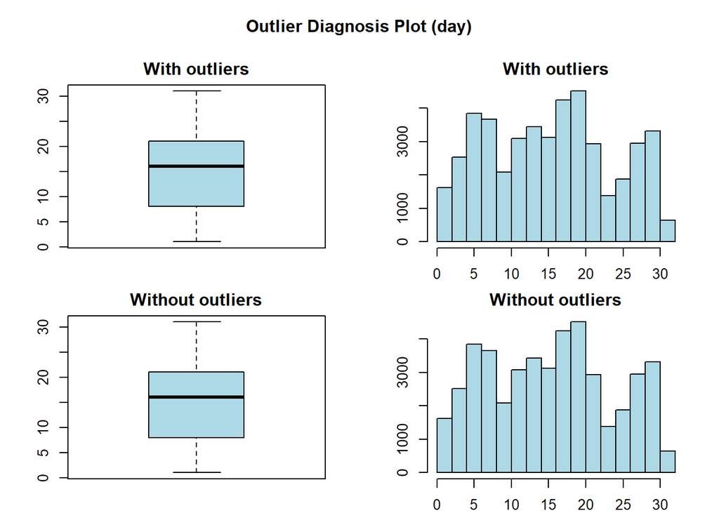

```r
bank %>%
  plot_outlier(day)
```

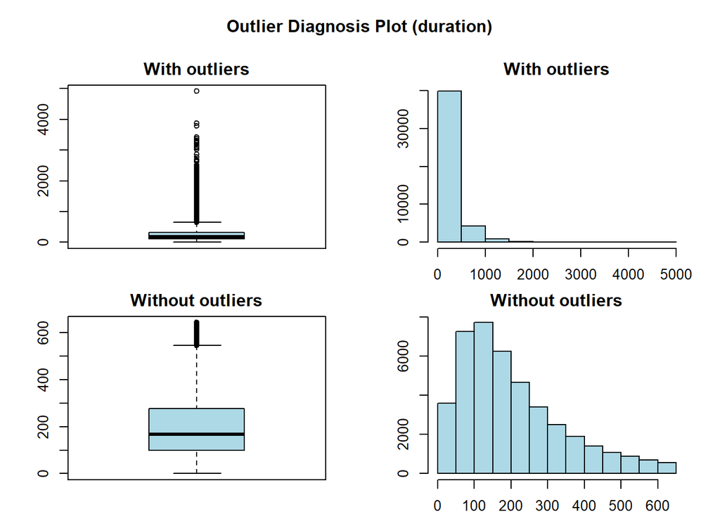

```r
bank %>%
  plot_outlier(duration)
```

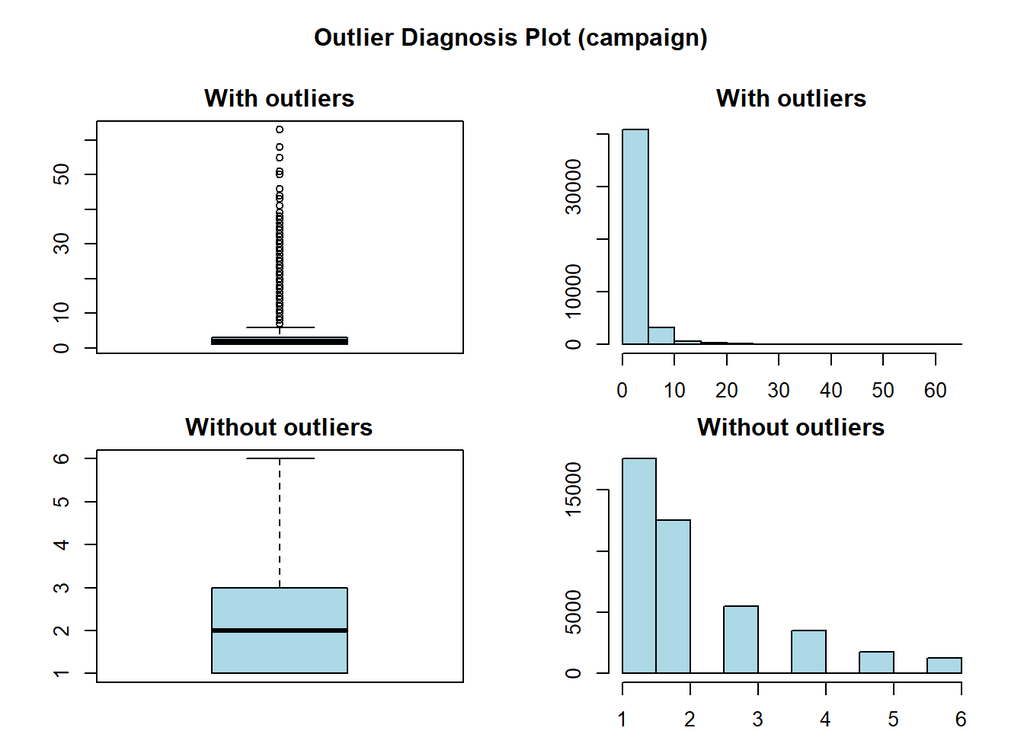

```r
bank %>%
  plot_outlier(campaign)
```

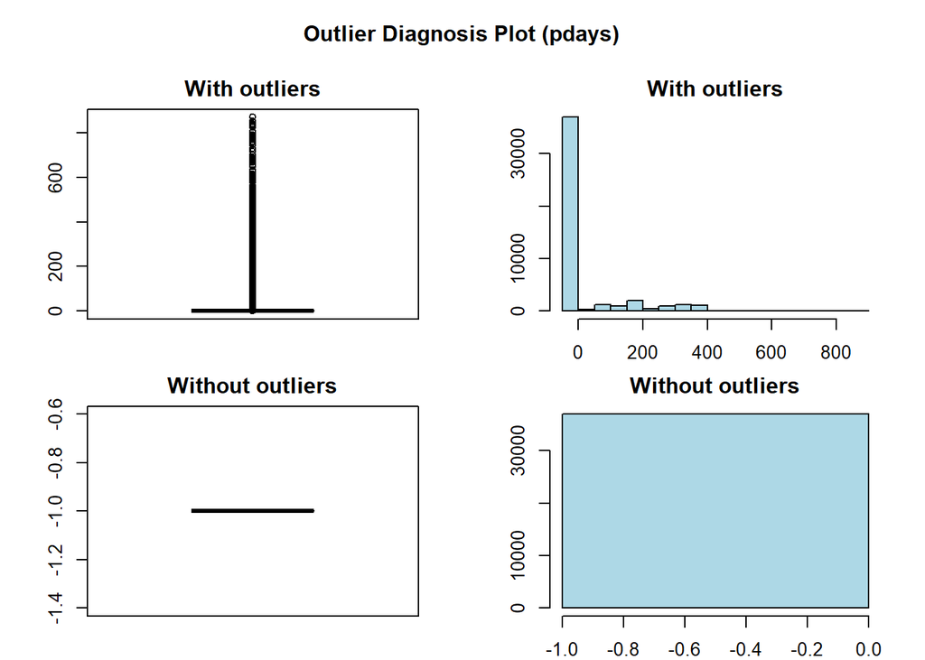

```r
bank %>%
  plot_outlier(pdays)
```

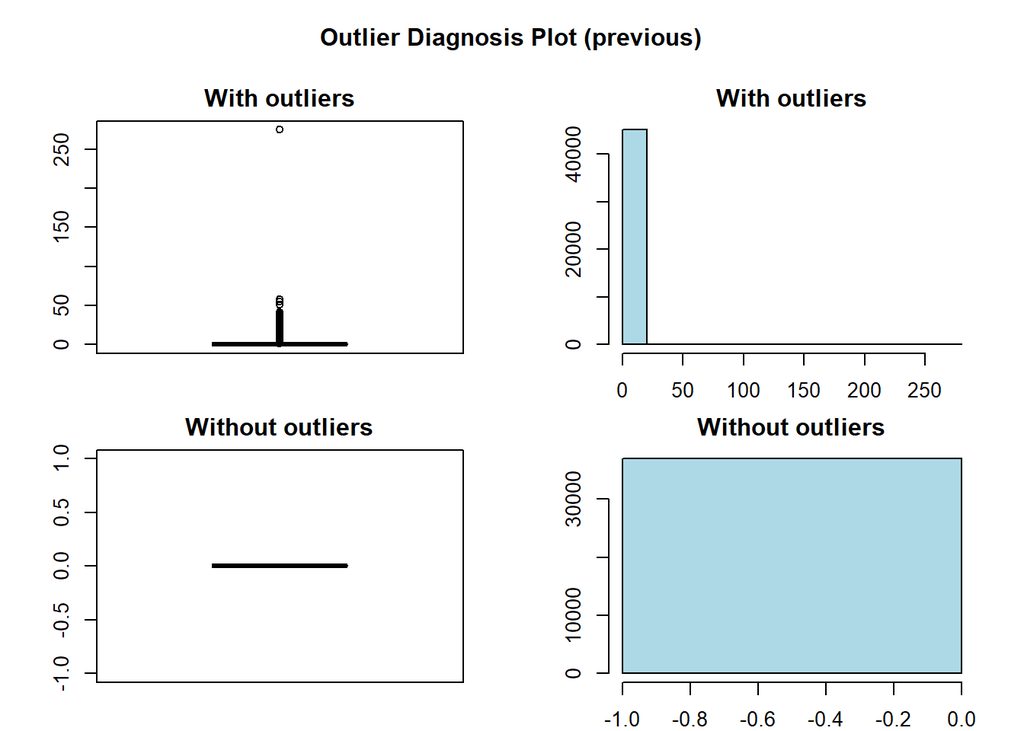

```r
bank %>%
  plot_outlier(previous)
```

Data Standardization: As mentioned above, the outliers the bottom 5 percentile and top 95 percentile data were capped for some of the continuous variables as given below. The capping resulted in reduction in outliers. The capped data are binded to the master data as separate columns.

```r
# Imputation of Outlier through 95% upper and 5% lower Capping

age_imp <- imputate_outlier(bank, age, method = "capping")
summary(age_imp)
```

```
## Impute outliers with capping
##
## * Information of Imputation (before vs after)
##              Original    Imputation
## n        4.521100e+04  4.521100e+04
## na       0.000000e+00  0.000000e+00
## mean     4.093621e+01  4.074431e+01
## sd       1.061876e+01  1.010553e+01
## se_mean  4.994038e-02  4.752661e-02
## IQR      1.500000e+01  1.500000e+01
## skewness 6.848179e-01  4.039484e-01
## kurtosis 3.195704e-01 -7.281184e-01
## p00      1.800000e+01  1.800000e+01
## p01      2.300000e+01  2.300000e+01
## p05      2.700000e+01  2.700000e+01
## p10      2.900000e+01  2.900000e+01
## p20      3.200000e+01  3.200000e+01
## p25      3.300000e+01  3.300000e+01
## p30      3.400000e+01  3.400000e+01
## p40      3.600000e+01  3.600000e+01
## p50      3.900000e+01  3.900000e+01
## p60      4.200000e+01  4.200000e+01
## p70      4.600000e+01  4.600000e+01
## p75      4.800000e+01  4.800000e+01
## p80      5.100000e+01  5.100000e+01
## p90      5.600000e+01  5.600000e+01
## p95      5.900000e+01  5.900000e+01
## p99      7.100000e+01  6.300000e+01
## p100     9.500000e+01  7.000000e+01
```

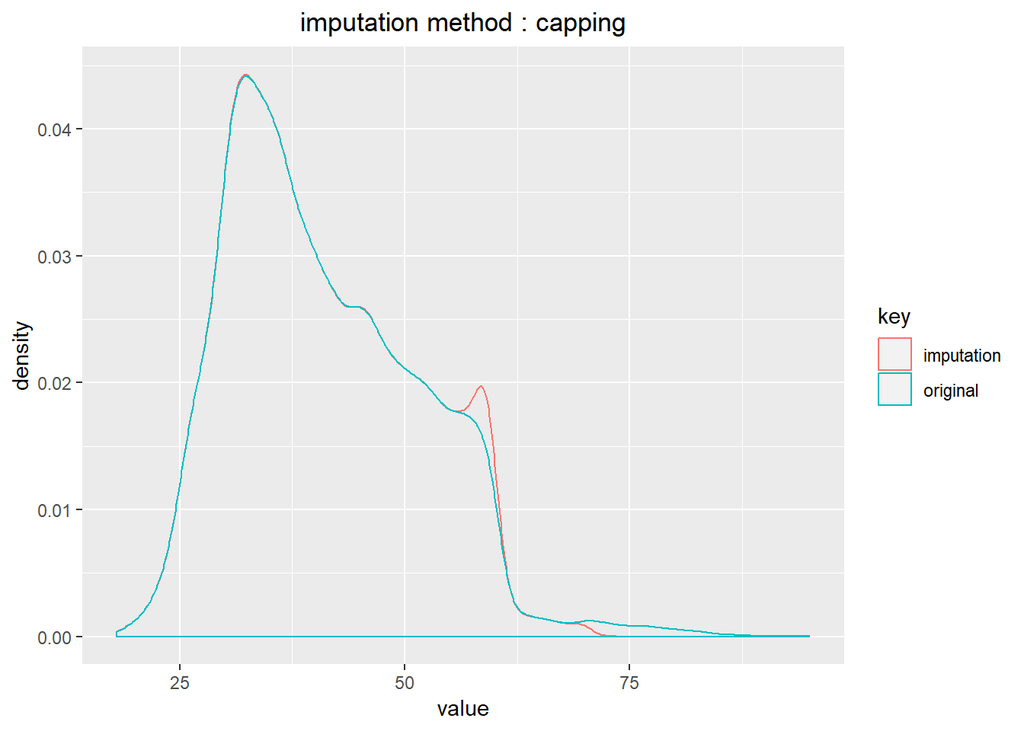

```r
plot(age_imp)
```

```r
bank <-cbind(bank,age_imp)

balance_imp <- imputate_outlier(bank, balance, method = "capping")
summary(balance_imp)
```

```
## Impute outliers with capping
##
## * Information of Imputation (before vs after)
##               Original   Imputation
## n         45211.000000 45211.000000
## na            0.000000     0.000000
## mean       1362.272058  1174.716949
## sd         3044.765829  1758.845268
## se_mean      14.319631     8.271906
## IQR        1356.000000  1356.000000
## skewness      8.360308     1.771347
## kurtosis    140.751547     2.019813
## p00       -8019.000000 -1944.000000
## p01        -627.000000  -616.900000
## p05        -172.000000  -172.000000
## p10           0.000000     0.000000
## p20          22.000000    22.000000
## p25          72.000000    72.000000
## p30         131.000000   131.000000
## p40         272.000000   272.000000
## p50         448.000000   448.000000
## p60         701.000000   701.000000
## p70        1126.000000  1126.000000
## p75        1428.000000  1428.000000
## p80        1859.000000  1859.000000
## p90        3574.000000  5768.000000
## p95        5768.000000  5768.000000
## p99       13164.900000  5768.000000
## p100     102127.000000  5768.000000
```